# Computational Notebook

Main Analysis for BP test-retest reliability

Published

September 8, 2026

```r
library(dplyr)
library(purrr)
library(tidyr)
library(ggplot2)
library(rstatix)
library(SimplyAgree)
library(boot.pval)
library(tidytext)
library(scales)

set_theme(theme_bw())
```

# Background

A great deal of research interest has focused on identifying breakpoints in NIRS-derived measures. Some studies report no significant difference between methods, while others find breakpoints at different workloads. A key challenge is that even when the mean difference between methods is small, individual-level agreement is often poor. This poor individual-level agreement may be driven by day-to-day variability in the NIRS breakpoints themselves or in the reference threshold used to validate them.

While the day-to-day variability of ventilatory and lactate thresholds has been extensively studied, the test-retest reliability of NIRS breakpoints remains largely unknown. Furthermore, although a wide range of NIRS breakpoint detection methods has been proposed, most have only been evaluated for criterion validity, not reliability.

Therefore, this exploratory analysis applies multiple breakpoint detection methods to a pre-existing data set of repeated incremental cycling tests and reports their test-retest reliability. The results should reveal differences between methods and inform future work on criterion validity and physiological interpretation of NIRS breakpoints.

## Breakpoint methods applied

Methods for BP1:

1. Visual identification
2. double segmented on the full data (raw)
3. double segmented on the stage mean SmO<sub>2</sub>
4. double segmented on the slope per stage
5. double segmented on the power/SmO<sub>2</sub> ratio
6. log-log method on stage mean SmO<sub>2</sub>
7. log-log method on the power/SmO<sub>2</sub> ratio
8. second derivative of 4th degree polynomial (1st inflection)

Methods for BP2:

1. Visual identification
2. double segmented on the full data (raw)
3. double segmented on the stage mean SmO<sub>2</sub>
4. double segmented on the slope per stage
5. double segmented on the power/SmO<sub>2</sub> ratio
6. Dmax method on stage mean SmO<sub>2</sub>
7. Dmax method on the power/SmO<sub>2</sub> ratio
8. modDmax method on stage mean SmO<sub>2</sub>
9. modDmax method on power/SmO<sub>2</sub> ratio
10. second derivative of 4th degree polynomial (2nd inflection)

## Load the data

The data was produced in the pre-processing pipeline, taking the raw recordings, applying smoothing, filtering (with `{mnirs}`) and calculating the different breakpoints.

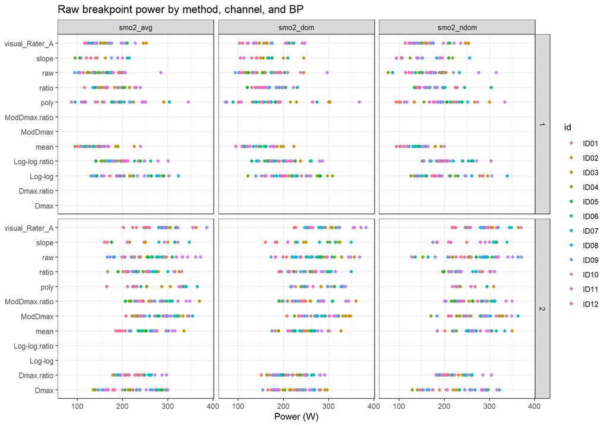

```r
dat <- read.csv("../../Data/AnalysisData/breakpoint_data.csv") |>
  mutate(bp2_type = NA_character_)

ratings <- read.csv("../../Data/ManualRatings/Rater_A_ratings.csv") |>
  mutate(
    method  = paste0("visual_", rater),
    warning = ifelse(!identifiable, "not_identifiable", NA_character_)
  ) |>
  select(session_id, channel, method, bp, bp_x, warning, power, bp2_type)

dat <- bind_rows(dat, ratings) |>
  mutate(
    id   = sub("_.*", "", session_id),
    test = sub(".*_", "", session_id)
  )

dat |>
    ggplot(aes(power, method, color = id)) +
    geom_point() +
    facet_grid(bp ~ channel) +
    labs(title = "Raw breakpoint power by method, channel, and BP", x = "Power (W)", y = NULL)
```

```r
# now get subsets for dom, ndom and avg

dat_dom <- dat |>
  dplyr::filter(channel == "smo2_dom")

dat_ndom <- dat |>
  dplyr::filter(channel == "smo2_ndom")

dat_avg <- dat |>
  dplyr::filter(channel == "smo2_avg")

dat_dom_wide <- dat_dom |>
  pivot_wider(
    id_cols    = c(id, method, bp),
    names_from = test,
    values_from = power,
    names_prefix = "T"
  ) |>
  mutate(
    mean_power = apply(pick(T01, T02, T03), 1, mean, na.rm = TRUE),
    sd_power   = apply(pick(T01, T02, T03), 1, sd,   na.rm = TRUE),
    cv_power   = sd_power / mean_power * 100,
    channel    = "DOM"
  )

dat_ndom_wide <- dat_ndom |>
  pivot_wider(
    id_cols    = c(id, method, bp),
    names_from = test,
    values_from = power,
    names_prefix = "T"
  ) |>
  mutate(
    mean_power = apply(pick(T01, T02, T03), 1, mean, na.rm = TRUE),
    sd_power   = apply(pick(T01, T02, T03), 1, sd,   na.rm = TRUE),
    cv_power   = sd_power / mean_power * 100,
    channel    = "NDOM"
  )

dat_avg_wide <- dat_avg |>
  pivot_wider(
    id_cols    = c(id, method, bp),
    names_from = test,
    values_from = power,
    names_prefix = "T"
  ) |>
  mutate(
    mean_power = apply(pick(T01, T02, T03), 1, mean, na.rm = TRUE),
    sd_power   = apply(pick(T01, T02, T03), 1, sd,   na.rm = TRUE),
    cv_power   = sd_power / mean_power * 100,
    channel    = "AVG"
  )

dat_all_wide <- bind_rows(dat_dom_wide, dat_ndom_wide, dat_avg_wide)
```

## Assumption testing

Before proceeding to get estimands for test-retest reliability, test some assumptions.

### Normality

Look at q-q plots and run a Shapiro-Wilk

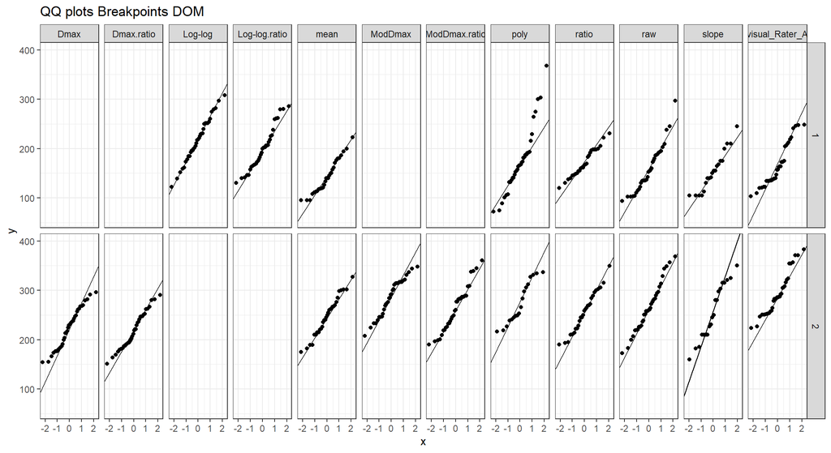

```r
# for DOM
dat_dom |>
  ggplot(aes(sample = power)) +
  stat_qq() +
  stat_qq_line() +
  facet_grid(bp ~ method) +
  labs(title = "QQ plots Breakpoints DOM")
```

```r
dat_dom |>
  group_by(method, bp) |>
  rstatix::shapiro_test(power)
```

```
# A tibble: 18 × 5
   method            bp variable statistic       p
   <chr>          <int> <chr>        <dbl>   <dbl>
 1 Dmax               2 power        0.963 0.273
 2 Dmax.ratio         2 power        0.966 0.318
 3 Log-log            1 power        0.991 0.993
 4 Log-log.ratio      1 power        0.950 0.117
 5 ModDmax            2 power        0.954 0.158
 6 ModDmax.ratio      2 power        0.962 0.255
 7 mean               1 power        0.949 0.164
 8 mean               2 power        0.978 0.776
 9 poly               1 power        0.925 0.0203
10 poly               2 power        0.904 0.0675
11 ratio              1 power        0.966 0.505
12 ratio              2 power        0.974 0.699
13 raw                1 power        0.936 0.0370
14 raw                2 power        0.979 0.717
15 slope              1 power        0.936 0.204
16 slope              2 power        0.945 0.297
17 visual_Rater_A     1 power        0.908 0.00551
18 visual_Rater_A     2 power        0.935 0.0428
```

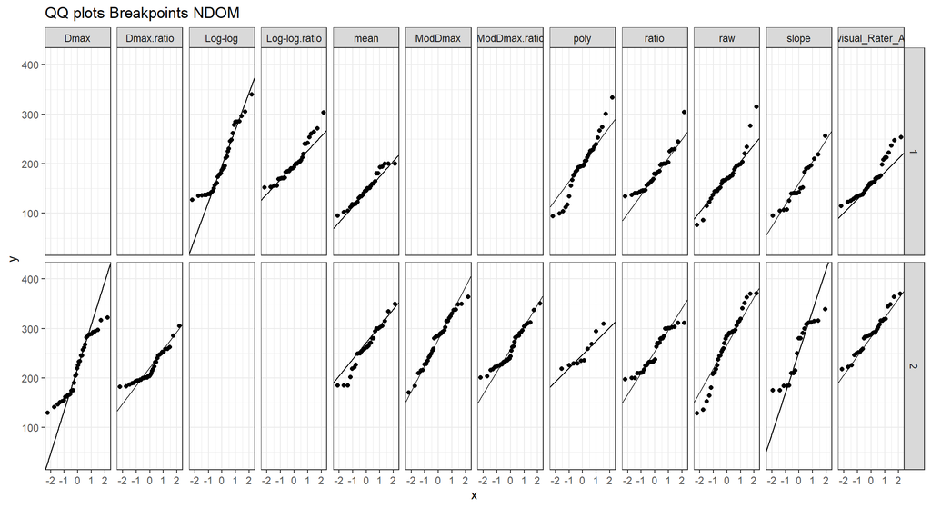

```r
# for NDOM
dat_ndom |>
  ggplot(aes(sample = power)) +
  stat_qq() +
  stat_qq_line() +
  facet_grid(bp ~ method) +
  labs(title = "QQ plots Breakpoints NDOM")
```

```r
dat_ndom |>
  group_by(method, bp) |>
  rstatix::shapiro_test(power)
```

```
# A tibble: 18 × 5
   method            bp variable statistic       p
   <chr>          <int> <chr>        <dbl>   <dbl>
 1 Dmax               2 power        0.921 0.0135
 2 Dmax.ratio         2 power        0.891 0.00196
 3 Log-log            1 power        0.911 0.00774
 4 Log-log.ratio      1 power        0.923 0.0172
 5 ModDmax            2 power        0.973 0.524
 6 ModDmax.ratio      2 power        0.934 0.0378
 7 mean               1 power        0.952 0.210
 8 mean               2 power        0.967 0.486
 9 poly               1 power        0.965 0.333
10 poly               2 power        0.858 0.0727
11 ratio              1 power        0.901 0.00499
12 ratio              2 power        0.906 0.00678
13 raw                1 power        0.930 0.0257
14 raw                2 power        0.955 0.146
15 slope              1 power        0.940 0.266
16 slope              2 power        0.869 0.0137
17 visual_Rater_A     1 power        0.912 0.00716
18 visual_Rater_A     2 power        0.964 0.362
```

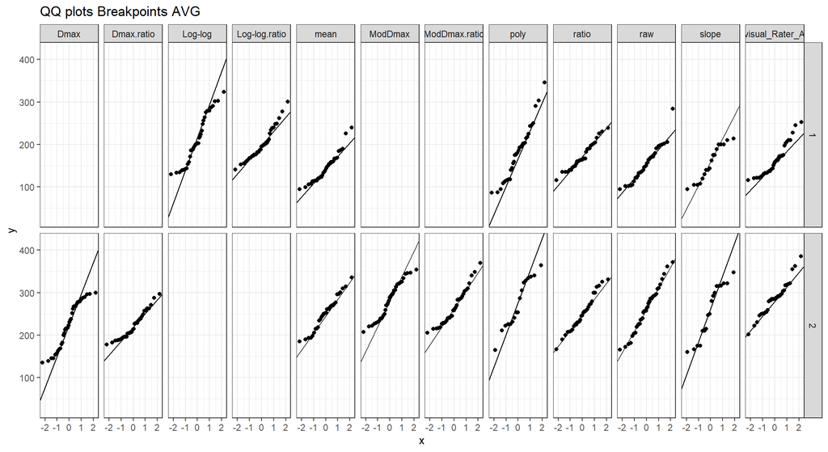

```r
# for AVG
dat_avg |>
  ggplot(aes(sample = power)) +
  stat_qq() +
  stat_qq_line() +
  facet_grid(bp ~ method) +
  labs(title = "QQ plots Breakpoints AVG")
```

```r
dat_dom |>
  group_by(method, bp) |>
  rstatix::shapiro_test(power)
```

```
# A tibble: 18 × 5
   method            bp variable statistic       p
   <chr>          <int> <chr>        <dbl>   <dbl>
 1 Dmax               2 power        0.963 0.273
 2 Dmax.ratio         2 power        0.966 0.318
 3 Log-log            1 power        0.991 0.993
 4 Log-log.ratio      1 power        0.950 0.117
 5 ModDmax            2 power        0.954 0.158
 6 ModDmax.ratio      2 power        0.962 0.255
 7 mean               1 power        0.949 0.164
 8 mean               2 power        0.978 0.776
 9 poly               1 power        0.925 0.0203
10 poly               2 power        0.904 0.0675
11 ratio              1 power        0.966 0.505
12 ratio              2 power        0.974 0.699
13 raw                1 power        0.936 0.0370
14 raw                2 power        0.979 0.717
15 slope              1 power        0.936 0.204
16 slope              2 power        0.945 0.297
17 visual_Rater_A     1 power        0.908 0.00551
18 visual_Rater_A     2 power        0.935 0.0428
```

### Homoscedasticity

Homoscedasticity of within-subject variability is assessed by plotting absolute pairwise differences against the mean threshold, for each method.

```r
# for dom
# formal test using rank-order correlation
dat_dom_wide |>
  group_by(method, bp) |>
  filter(!is.na(T01) & !is.na(T02)) |>
  summarize(
    tryCatch(
      broom::tidy(
        cor.test(abs(T01 - T02), (T01 + T02) / 2,
        method = "spearman", exact = FALSE)
      ) |> select(estimate, p.value),
      error = function(e) tibble(estimate = NA_real_, p.value = NA_real_)
    ),
    n = n(),
    .groups = "drop"
  ) |>
  select(method, bp, rho = estimate, p.value, n)
```

```
# A tibble: 18 × 5
   method            bp     rho p.value     n
   <chr>          <int>   <dbl>   <dbl> <int>
 1 Dmax               2 -0.126    0.697    12
 2 Dmax.ratio         2 -0.161    0.618    12
 3 Log-log            1 -0.462    0.131    12
 4 Log-log.ratio      1 -0.105    0.746    12
 5 ModDmax            2  0.336    0.312    11
 6 ModDmax.ratio      2 -0.238    0.457    12
 7 mean               1  0.238    0.570     8
 8 mean               2 -0.238    0.570     8
 9 poly               1  0.4      0.223    11
10 poly               2  1      NaN         2
11 ratio              1  0.0476   0.911     8
12 ratio              2  0.0714   0.867     8
13 raw                1  0.420    0.175    12
14 raw                2 -0.5      0.117    11
15 slope              1  0.5      0.667     3
16 slope              2  0.5      0.667     3
17 visual_Rater_A     1  0.427    0.167    12
18 visual_Rater_A     2  0.285    0.425    10
```

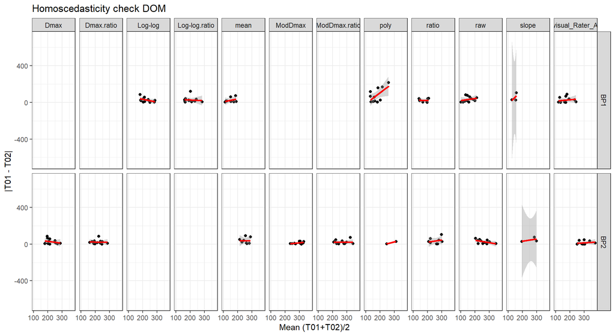

```r
  # Visual (primary evidence) — faceted across all 12 panels
dat_dom_wide |>
  filter(!is.na(T01), !is.na(T02)) |>
  mutate(
    abs_diff = abs(T01 - T02),
    mean_val = (T01 + T02) / 2,
    bp = factor(bp, levels = c(1, 2), labels = c("BP1", "BP2"))
  ) |>
  ggplot(aes(x = mean_val, y = abs_diff)) +
  geom_point() +
  geom_smooth(method = "lm", se = TRUE, color = "red") +
  facet_grid(bp ~ method) +
  labs(x = "Mean (T01+T02)/2", y = "|T01 - T02|",
       title = "Homoscedasticity check DOM")
```

```r
# for ndom
# formal test using rank-order correlation
dat_ndom_wide |>
  group_by(method, bp) |>
  filter(!is.na(T01) & !is.na(T02)) |>
  summarize(
    tryCatch(
      broom::tidy(
        cor.test(abs(T01 - T02), (T01 + T02) / 2,
        method = "spearman", exact = FALSE)
      ) |> select(estimate, p.value),
      error = function(e) tibble(estimate = NA_real_, p.value = NA_real_)
    ),
    n = n(),
    .groups = "drop"
  ) |>
  select(method, bp, rho = estimate, p.value, n)
```

```
# A tibble: 18 × 5
   method            bp     rho   p.value     n
   <chr>          <int>   <dbl>     <dbl> <int>
 1 Dmax               2 -0.336    0.286      12
 2 Dmax.ratio         2 -0.0420   0.897      12
 3 Log-log            1  0.378    0.226      12
 4 Log-log.ratio      1 -0.0140   0.966      12
 5 ModDmax            2  0.0979   0.762      12
 6 ModDmax.ratio      2  0.231    0.471      12
 7 mean               1 -0.476    0.233       8
 8 mean               2  0.214    0.610       8
 9 poly               1  0.664    0.0260     11
10 poly               2  1      NaN           2
11 ratio              1  0.445    0.170      11
12 ratio              2  0.0545   0.873      11
13 raw                1  0.531    0.0754     12
14 raw                2 -0.762    0.00395    12
15 slope              1  0.8      0.200       4
16 slope              2  0.4      0.6         4
17 visual_Rater_A     1  0.161    0.618      12
18 visual_Rater_A     2  0.103    0.777      10
```

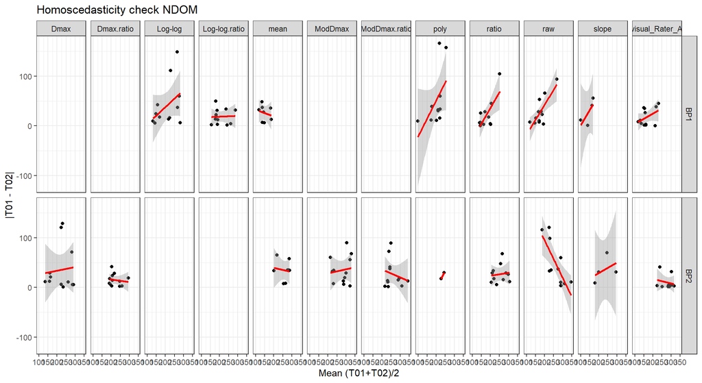

```r
# Visual (primary evidence) — faceted across all 12 panels
dat_ndom_wide |>
  filter(!is.na(T01), !is.na(T02)) |>
  mutate(
    abs_diff = abs(T01 - T02),
    mean_val = (T01 + T02) / 2,
    bp = factor(bp, levels = c(1, 2), labels = c("BP1", "BP2"))
  ) |>
  ggplot(aes(x = mean_val, y = abs_diff)) +
  geom_point() +
  geom_smooth(method = "lm", se = TRUE, color = "red") +
  facet_grid(bp ~ method) +
  labs(x = "Mean (T01+T02)/2", y = "|T01 - T02|",
       title = "Homoscedasticity check NDOM")
```

```r
# for avg
# formal test using rank-order correlation
dat_avg_wide |>
  group_by(method, bp) |>
  filter(!is.na(T01) & !is.na(T02)) |>
  summarize(
    tryCatch(
      broom::tidy(
        cor.test(abs(T01 - T02), (T01 + T02) / 2,
        method = "spearman", exact = FALSE)
      ) |> select(estimate, p.value),
      error = function(e) tibble(estimate = NA_real_, p.value = NA_real_)
    ),
    n = n(),
    .groups = "drop"
  ) |>
  select(method, bp, rho = estimate, p.value, n)
```

```
# A tibble: 18 × 5
   method            bp     rho p.value     n
   <chr>          <int>   <dbl>   <dbl> <int>
 1 Dmax               2 -0.203   0.527     12
 2 Dmax.ratio         2  0.252   0.430     12
 3 Log-log            1  0.294   0.354     12
 4 Log-log.ratio      1  0.252   0.430     12
 5 ModDmax            2  0.126   0.697     12
 6 ModDmax.ratio      2  0.315   0.319     12
 7 mean               1  0.0303  0.934     10
 8 mean               2  0.406   0.244     10
 9 poly               1 -0.0182  0.958     11
10 poly               2 -0.8     0.200      4
11 ratio              1 -0.119   0.779      8
12 ratio              2  0.548   0.160      8
13 raw                1  0.552   0.0625    12
14 raw                2 -0.0350  0.914     12
15 slope              1 NA      NA          1
16 slope              2 NA      NA          1
17 visual_Rater_A     1  0.357   0.255     12
18 visual_Rater_A     2  0.264   0.433     11
```

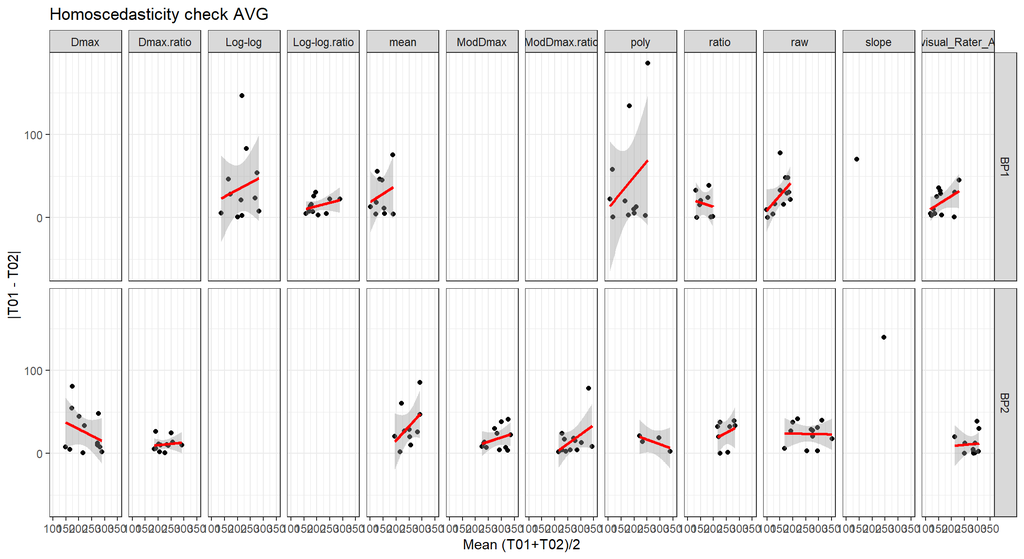

```r
# Visual (primary evidence) — faceted across all 12 panels
dat_avg_wide |>
  filter(!is.na(T01), !is.na(T02)) |>
  mutate(
    abs_diff = abs(T01 - T02),
    mean_val = (T01 + T02) / 2,
    bp = factor(bp, levels = c(1, 2), labels = c("BP1", "BP2"))
  ) |>
  ggplot(aes(x = mean_val, y = abs_diff)) +
  geom_point() +
  geom_smooth(method = "lm", se = TRUE, color = "red") +
  facet_grid(bp ~ method) +
  labs(x = "Mean (T01+T02)/2", y = "|T01 - T02|",
       title = "Homoscedasticity check AVG")
```

### Systematic trial effect

With non-normal data, simply use Friedman test to look at order effects.

```r
# for DOM
dat_dom |>
  group_by(method, bp, id) |>
  filter(n() == 3, !any(is.na(power))) |>
  group_by(method, bp) |>
  nest() |>
  mutate(result = map(data, \(d) {
    tryCatch({
      res <- friedman.test(power ~ test | id, data = d)
      tibble(statistic = res$statistic, df = res$parameter, p.value = res$p.value)
    }, error = function(e) {
      tibble(statistic = NA_real_, df = NA_integer_, p.value = NA_real_)
    })
  })) |>
  select(-data) |>
  unnest(result)
```

```
# A tibble: 18 × 5
# Groups:   method, bp [18]
   method            bp statistic    df p.value
   <chr>          <int>     <dbl> <dbl>   <dbl>
 1 raw                1     1.17      2  0.558
 2 raw                2     2.36      2  0.307
 3 mean               1     0.286     2  0.867
 4 mean               2     0.286     2  0.867
 5 ratio              1     4.33      2  0.115
 6 ratio              2     6.33      2  0.0421
 7 Log-log            1     2.36      2  0.307
 8 Dmax               2     3.5       2  0.174
 9 ModDmax            2     0.6       2  0.741
10 Log-log.ratio      1     1.64      2  0.441
11 Dmax.ratio         2     1.17      2  0.558
12 ModDmax.ratio      2     1.27      2  0.529
13 poly               1     2.36      2  0.307
14 slope              1     0.545     2  0.761
15 slope              2     3.82      2  0.148
16 poly               2     1         2  0.607
17 visual_Rater_A     1     0.5       2  0.779
18 visual_Rater_A     2     1.4       2  0.497
```

```r
# for NDOM
dat_ndom |>
  group_by(method, bp, id) |>
  filter(n() == 3, !any(is.na(power))) |>
  group_by(method, bp) |>
  nest() |>
  mutate(result = map(data, \(d) {
    tryCatch({
      res <- friedman.test(power ~ test | id, data = d)
      tibble(statistic = res$statistic, df = res$parameter, p.value = res$p.value)
    }, error = function(e) {
      tibble(statistic = NA_real_, df = NA_integer_, p.value = NA_real_)
    })
  })) |>
  select(-data) |>
  unnest(result)
```

```
# A tibble: 18 × 5
# Groups:   method, bp [18]
   method            bp statistic    df p.value
   <chr>          <int>     <dbl> <dbl>   <dbl>
 1 raw                1     0.5       2  0.779
 2 raw                2     0.667     2  0.717
 3 mean               1     0.452     2  0.798
 4 mean               2     5.10      2  0.0782
 5 ratio              1     3.23      2  0.199
 6 ratio              2     3.23      2  0.199
 7 Log-log            1     0         2  1
 8 Dmax               2     0.167     2  0.920
 9 ModDmax            2     3.82      2  0.148
10 Log-log.ratio      1     1.64      2  0.441
11 Dmax.ratio         2     2         2  0.368
12 ModDmax.ratio      2     2.91      2  0.234
13 poly               1     1.64      2  0.441
14 poly               2     1         2  0.607
15 slope              1    NA        NA NA
16 slope              2    NA        NA NA
17 visual_Rater_A     1     1.5       2  0.472
18 visual_Rater_A     2     6.22      2  0.0446
```

```r
# for AVG
dat_avg |>
  group_by(method, bp, id) |>
  filter(n() == 3, !any(is.na(power))) |>
  group_by(method, bp) |>
  nest() |>
  mutate(result = map(data, \(d) {
    tryCatch({
      res <- friedman.test(power ~ test | id, data = d)
      tibble(statistic = res$statistic, df = res$parameter, p.value = res$p.value)
    }, error = function(e) {
      tibble(statistic = NA_real_, df = NA_integer_, p.value = NA_real_)
    })
  })) |>
  select(-data) |>
  unnest(result)
```

```
# A tibble: 18 × 5
# Groups:   method, bp [18]
   method            bp statistic    df p.value
   <chr>          <int>     <dbl> <dbl>   <dbl>
 1 raw                1     0.298     2  0.862
 2 raw                2     4.67      2  0.0970
 3 mean               1     3         2  0.223
 4 mean               2     0.25      2  0.882
 5 ratio              1     0.857     2  0.651
 6 ratio              2     2         2  0.368
 7 Log-log            1     1.27      2  0.529
 8 Dmax               2     0.167     2  0.920
 9 ModDmax            2     0.727     2  0.695
10 Log-log.ratio      1     0.182     2  0.913
11 Dmax.ratio         2     2.17      2  0.338
12 ModDmax.ratio      2     1.27      2  0.529
13 poly               1     1.64      2  0.441
14 poly               2     3         2  0.223
15 slope              1    NA        NA NA
16 slope              2    NA        NA NA
17 visual_Rater_A     1     3.5       2  0.174
18 visual_Rater_A     2     1.27      2  0.529
```

## Breakpoint differences between sides

First, compare the power output at BP1 and BP2 between DOM, NDOM and AVG. Because normalitiy may not be assumed, compare via pairwise bootstrap.

```r
dat_diff <- dat |>
  mutate(channel = gsub("smo2_", "", channel)) |>   # smo2_dom → dom etc.
  pivot_wider(
    id_cols     = c(id, test, session_id, method, bp),
    names_from  = channel,
    values_from = c(power, bp_x)                    # keep both metrics wide
  )

set.seed(42)

side_diff_all <- dat_diff |>
  drop_na(power_dom, power_ndom, power_avg) |>
  group_by(method, bp) |>
  nest() |>
  mutate(result = map(data, \(d) {
    if (nrow(d) < 3) return(tibble(
      comparison = character(), n = integer(), mean_diff = numeric(),
      ci_lower = numeric(), ci_upper = numeric(), p_raw = numeric()
    ))
    tests <- list(
      dom_vs_ndom = boot_t_test(d$power_dom,  d$power_ndom, paired = TRUE, R = 9999),
      dom_vs_avg  = boot_t_test(d$power_dom,  d$power_avg,  paired = TRUE, R = 9999),
      ndom_vs_avg = boot_t_test(d$power_ndom, d$power_avg,  paired = TRUE, R = 9999)
    )
    tibble(
      comparison = names(tests),
      n          = nrow(d),
      mean_diff  = c(
        mean(d$power_dom  - d$power_ndom, na.rm = TRUE),
        mean(d$power_dom  - d$power_avg,  na.rm = TRUE),
        mean(d$power_ndom - d$power_avg,  na.rm = TRUE)
      ),
      ci_lower = map_dbl(tests, \(t) t$conf.int[1]),
      ci_upper = map_dbl(tests, \(t) t$conf.int[2]),
      p_raw    = map_dbl(tests, "p.value")
    )
  })) |>
  select(-data) |>
  unnest(result) |>
  mutate(sig = p_raw < 0.05)

side_diff_all
```

```
# A tibble: 54 × 9
# Groups:   method, bp [18]
   method    bp comparison      n mean_diff ci_lower ci_upper  p_raw sig
   <chr>  <int> <chr>       <int>     <dbl>    <dbl>    <dbl>  <dbl> <lgl>
 1 raw        1 dom_vs_ndom    36    -13.6    -28.0     0.800 0.0627 FALSE
 2 raw        1 dom_vs_avg     36      2.76    -6.37   15.5   0.562  FALSE
 3 raw        1 ndom_vs_avg    36     16.4      3.14   32.3   0.0150 TRUE
 4 raw        2 dom_vs_ndom    35     -1.01   -14.8    16.0   0.911  FALSE
 5 raw        2 dom_vs_avg     35      5.98    -3.30   21.0   0.221  FALSE
 6 raw        2 ndom_vs_avg    35      7.00   -10.3    25.5   0.434  FALSE
 7 mean       1 dom_vs_ndom    23     -5.27   -16.5     5.13  0.298  FALSE
 8 mean       1 dom_vs_avg     23     -2.31    -8.98    4.73  0.547  FALSE
 9 mean       1 ndom_vs_avg    23      2.96    -5.80   11.3   0.498  FALSE
10 mean       2 dom_vs_ndom    23    -17.7    -36.9    -1.26  0.0382 TRUE
# ℹ 44 more rows
```

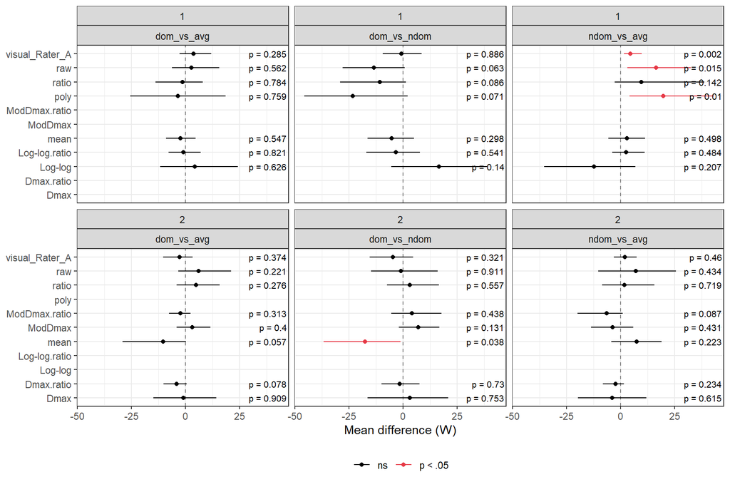

```r
side_diff_all |>
   filter(n >= 12) |>
  mutate(
    p_label = case_when(
      is.na(p_raw)  ~ "",
      p_raw < 0.001 ~ "p < .001",
      TRUE          ~ paste0("p = ", round(p_raw, 3))
    )
  ) |>
  ggplot(aes(mean_diff, method)) +
  geom_vline(xintercept = 0, linetype = "dashed", color = "grey50") +
  geom_linerange(aes(xmin = ci_lower, xmax = ci_upper, color = sig)) +
  geom_point(aes(color = sig)) +
  geom_text(aes(x = Inf, label = p_label), hjust = 1.05, size = 2.8) +
  scale_color_manual(values = c("FALSE" = "black", "TRUE" = "#e63946"),
                     labels = c("ns", "p < .05")) +
  facet_wrap(bp ~ comparison) +
  labs(x = "Mean difference (W)", y = NULL, color = NULL) +
    theme(legend.position = "bottom")
```

## Reliability quantification per method

### Failed breakpoint identification

A total of **36** tests were included (12 participants * 3 tests).

First, look at the number of breakpoints that could not be identified by method.

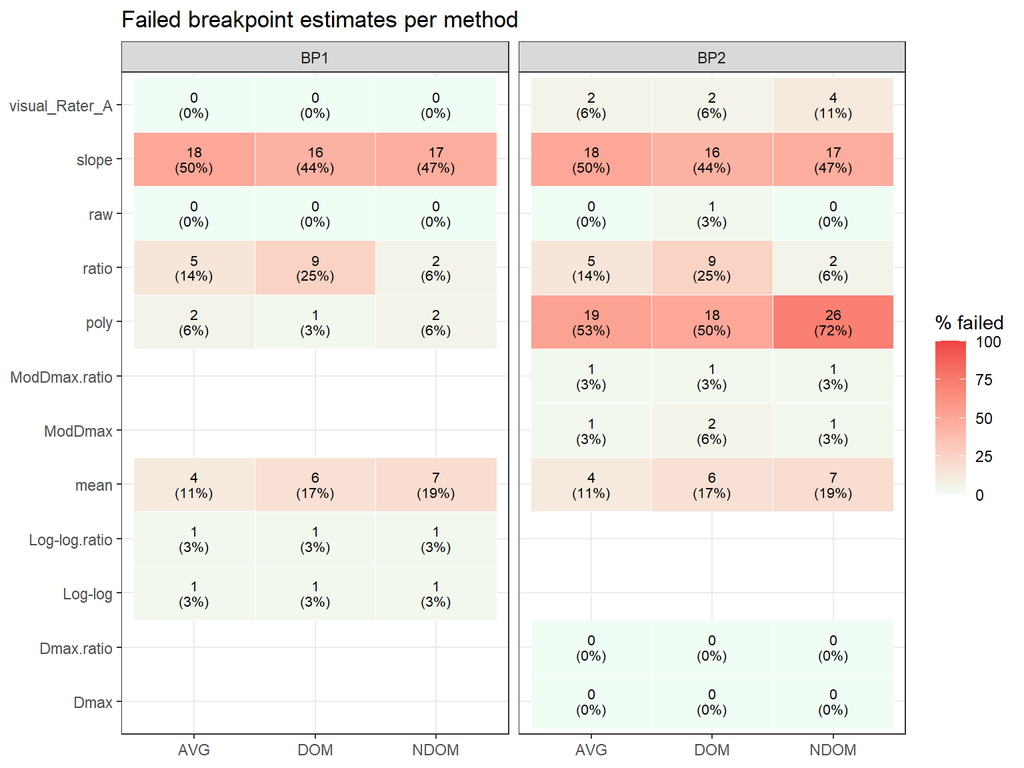

```r
bp_failed <- bind_rows(
  dat_dom  |> group_by(method, bp) |> summarize(n_total = n(), failed = sum(is.na(power)), .groups = "drop") |> mutate(channel = "DOM"),
  dat_ndom |> group_by(method, bp) |> summarize(n_total = n(), failed = sum(is.na(power)), .groups = "drop") |> mutate(channel = "NDOM"),
  dat_avg  |> group_by(method, bp) |> summarize(n_total = n(), failed = sum(is.na(power)), .groups = "drop") |> mutate(channel = "AVG")
) |>
  mutate(
    pct_failed  = round(failed / n_total * 100),
    low_success = (100 - pct_failed) < 33
  )

exclude_combos <- bp_failed |>
  filter(low_success) |>
  select(method, channel, bp)

bp_failed |>
  mutate(
    bp    = factor(bp, labels = c("BP1", "BP2")),
    label = paste0(failed, "\n(", pct_failed, "%)")
  ) |>
  ggplot(aes(x = channel, y = method, fill = pct_failed)) +
  geom_tile(color = "white") +
  geom_text(aes(label = label), size = 2.8, lineheight = 0.9) +
  scale_fill_gradient(low = "#f0fdf4", high = "#ef4444",
                      name = "% failed", limits = c(0, 100)) +
  facet_wrap(~ bp) +
  labs(x = NULL, y = NULL, title = "Failed breakpoint estimates per method")
```

Then, look which type of visual BP2s were identified.

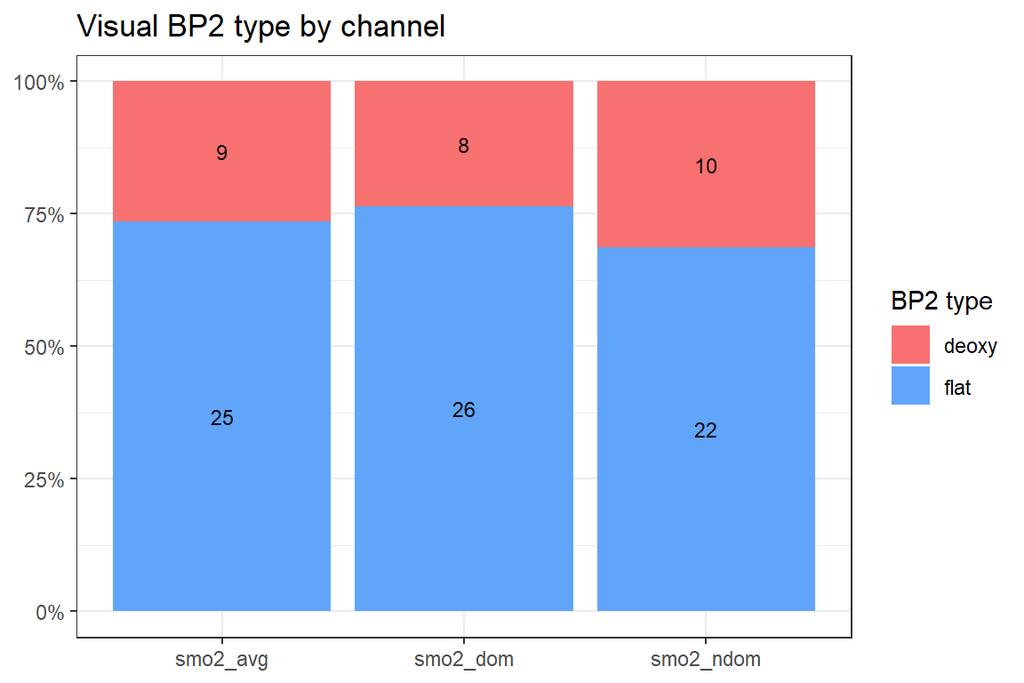

```r
bp2_visual <- dat |>
  filter(!is.na(bp2_type)) |>
  group_by(channel, bp2_type) |>
  summarize(n = n(), .groups = "drop")

bp2_visual |>
  group_by(channel) |>
  mutate(pct = n / sum(n)) |>
  ggplot(aes(x = channel, y = pct, fill = bp2_type)) +
  geom_col() +
  geom_text(aes(label = n), position = position_stack(vjust = 0.5), size = 3) +
  scale_y_continuous(labels = scales::percent) +
  scale_fill_manual(values = c("flat" = "#60a5fa", "deoxy" = "#f87171")) +
  labs(x = NULL, y = NULL, fill = "BP2 type",
       title = "Visual BP2 type by channel")
```

### Reliability statistics

Calculate ICC(2,1) with 95% CI for each method. Select absolute agreement, two-way random effects, single measures.

```r
icc_dom <- dat_dom_wide |>
  group_by(method, bp) |>
  nest() |>
  mutate(result = map(data, \(d) {
    tryCatch({
      res <- SimplyAgree::reli_stats(
        data = d, wide = TRUE, col.names = c("T01", "T02", "T03")
      )
      tibble(
        n         = res$n.id,
        icc       = res$icc$icc[res$icc$type == "ICC2"],
        icc_lower = res$icc$lower.ci[res$icc$type == "ICC2"],
        icc_upper = res$icc$upper.ci[res$icc$type == "ICC2"],
        sem       = res$SEM$estimate,
        cv        = res$cv$estimate,
        mdc95     = res$SEM$estimate * 1.96 * sqrt(2)
      )
    }, error = function(e) {
      tibble(n = NA_integer_, icc = NA_real_, icc_lower = NA_real_, icc_upper = NA_real_,
             sem = NA_real_, cv = NA_real_, mdc95 = NA_real_)
    })
  })) |>
  select(-data) |>
  unnest(result) |>
  mutate(channel = "DOM")
```

[output not shown]

```r
icc_ndom <- dat_ndom_wide |>
  group_by(method, bp) |>
  nest() |>
  mutate(result = map(data, \(d) {
    tryCatch({
      res <- SimplyAgree::reli_stats(
        data = d, wide = TRUE, col.names = c("T01", "T02", "T03")
      )
      tibble(
        n         = res$n.id,
        icc       = res$icc$icc[res$icc$type == "ICC2"],
        icc_lower = res$icc$lower.ci[res$icc$type == "ICC2"],
        icc_upper = res$icc$upper.ci[res$icc$type == "ICC2"],
        sem       = res$SEM$estimate,
        cv        = res$cv$estimate,
        mdc95     = res$SEM$estimate * 1.96 * sqrt(2)
      )
    }, error = function(e) {
      tibble(n = NA_integer_, icc = NA_real_, icc_lower = NA_real_, icc_upper = NA_real_,
             sem = NA_real_, cv = NA_real_, mdc95 = NA_real_)
    })
  })) |>
  select(-data) |>
  unnest(result) |>
  mutate(channel = "NDOM")
```

[output not shown]

```r
icc_avg <- dat_avg_wide |>
  group_by(method, bp) |>
  nest() |>
  mutate(result = map(data, \(d) {
    tryCatch({
      res <- SimplyAgree::reli_stats(
        data = d, wide = TRUE, col.names = c("T01", "T02", "T03")
      )
      tibble(
        n         = res$n.id,
        icc       = res$icc$icc[res$icc$type == "ICC2"],
        icc_lower = res$icc$lower.ci[res$icc$type == "ICC2"],
        icc_upper = res$icc$upper.ci[res$icc$type == "ICC2"],
        sem       = res$SEM$estimate,
        cv        = res$cv$estimate,
        mdc95     = res$SEM$estimate * 1.96 * sqrt(2)
      )
    }, error = function(e) {
      tibble(n = NA_integer_, icc = NA_real_, icc_lower = NA_real_, icc_upper = NA_real_,
             sem = NA_real_, cv = NA_real_, mdc95 = NA_real_)
    })
  })) |>
  select(-data) |>
  unnest(result) |>
  mutate(channel = "AVG")
```

[output not shown]

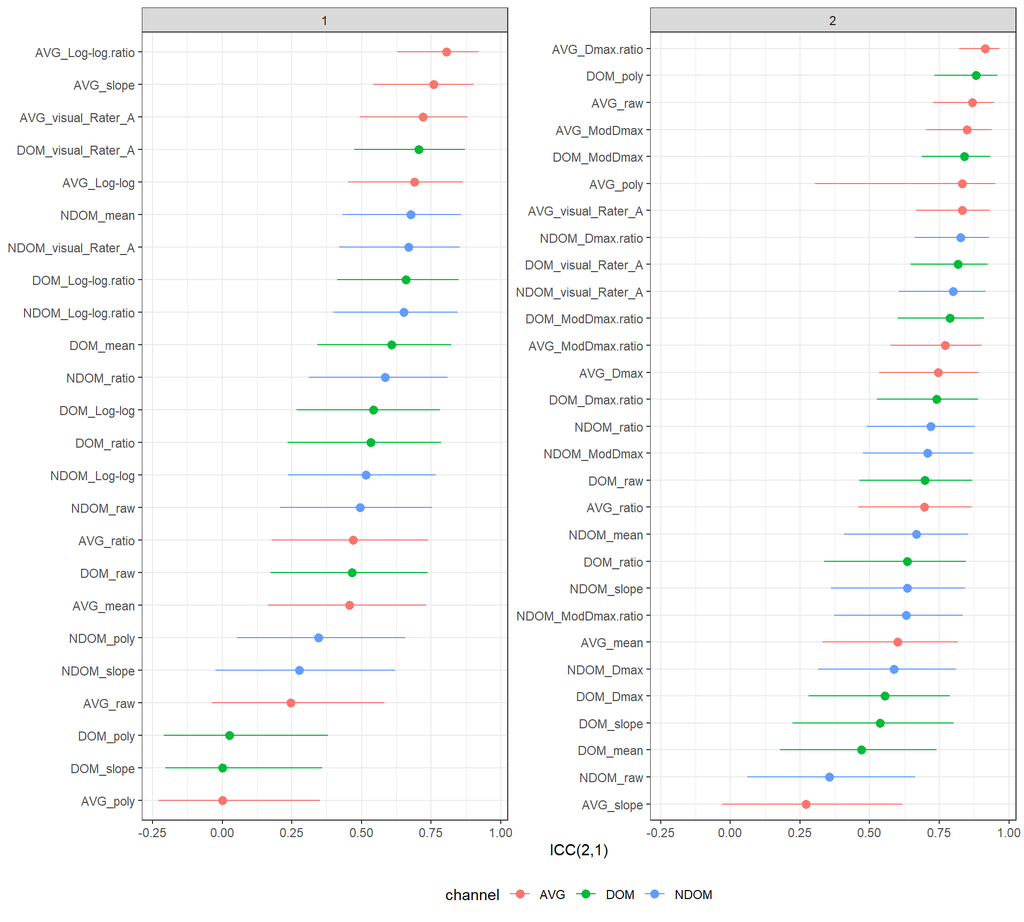

```r
icc_all <- bind_rows(icc_dom, icc_ndom, icc_avg)

# plot the results ordered by icc
icc_all <- icc_all |>
  group_by(bp) |>
  arrange(desc(icc)) |>
  ungroup() |>
  mutate(combination = interaction(channel, method, sep = "_"))

dir.create("../../Data/AnalysisData", showWarnings = FALSE, recursive = TRUE)
saveRDS(icc_all, "../../Data/AnalysisData/icc_all.rds")

icc_all |>
  # filter(n >= 12) |>
  anti_join(exclude_combos, by = c("method", "channel", "bp")) |>
  ggplot(aes(x = icc, y = tidytext::reorder_within(combination, icc, bp), color = channel)) +
  geom_point() +
  geom_pointrange(aes(xmin = icc_lower, xmax = icc_upper)) +
  tidytext::scale_y_reordered() +
  facet_wrap(~ bp, scales = "free_y") +
  labs(x = "ICC(2,1)", y = NULL) +
  theme(legend.position = "bottom")
```

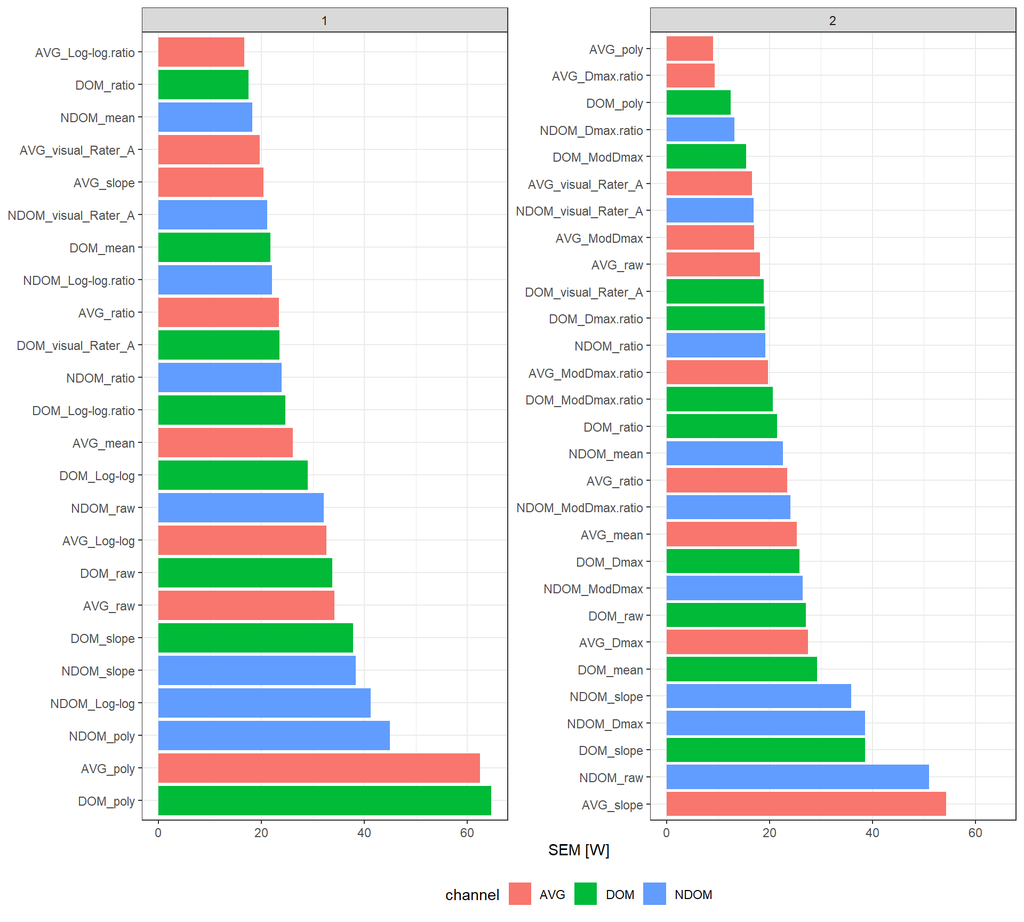

```r
icc_all |>
  # filter(n >= 12) |>
  anti_join(exclude_combos, by = c("method", "channel", "bp")) |>
  ggplot(aes(x = sem, y = tidytext::reorder_within(combination, -sem, bp), fill = channel)) +
  geom_bar(stat = "identity") +
  tidytext::scale_y_reordered() +
  facet_wrap(~ bp, scales = "free_y") +
  labs(x = "SEM [W]", y = NULL) +
  theme(legend.position = "bottom")
```

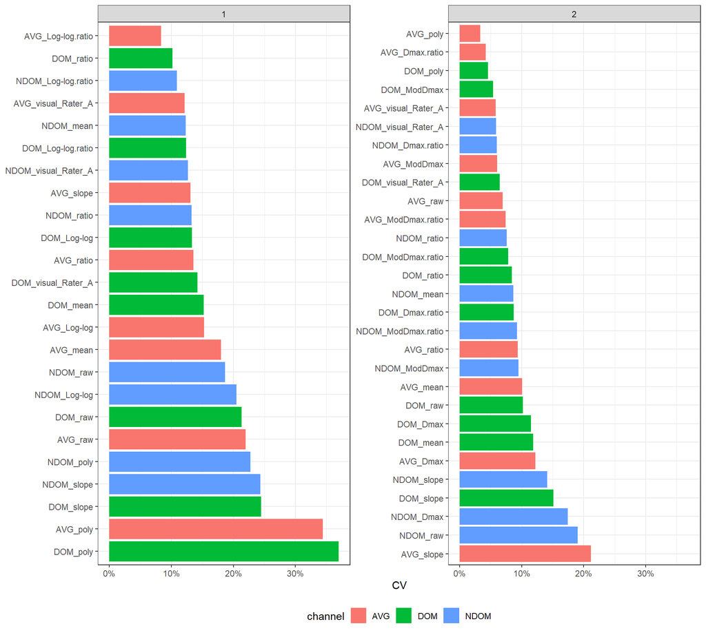

```r
icc_all |>
  # filter(n >= 12) |>
  anti_join(exclude_combos, by = c("method", "channel", "bp")) |>
  ggplot(aes(x = cv, y = tidytext::reorder_within(combination, -cv, bp), fill = channel)) +
  geom_bar(stat = "identity") +
  tidytext::scale_y_reordered() +
  scale_x_continuous(labels = percent) +
  facet_wrap(~ bp, scales = "free_y") +
  labs(x = "CV", y = NULL) +
  theme(legend.position = "bottom")
```

Calculate SEM (√MS_error from the two-way repeated measures ANOVA).

Calculate MDC₉₅ (SEM × 1.96 × √2).

## Comparing reliability between methods

Run the paired bootstrap for each method pair: resample the 12 participant-level pairs with replacement, compute the mean difference in within-subject SD and CV each iteration (10,000 resamples), derive the 95% CI. If the CI excludes zero, conclude the methods differ in reliability.

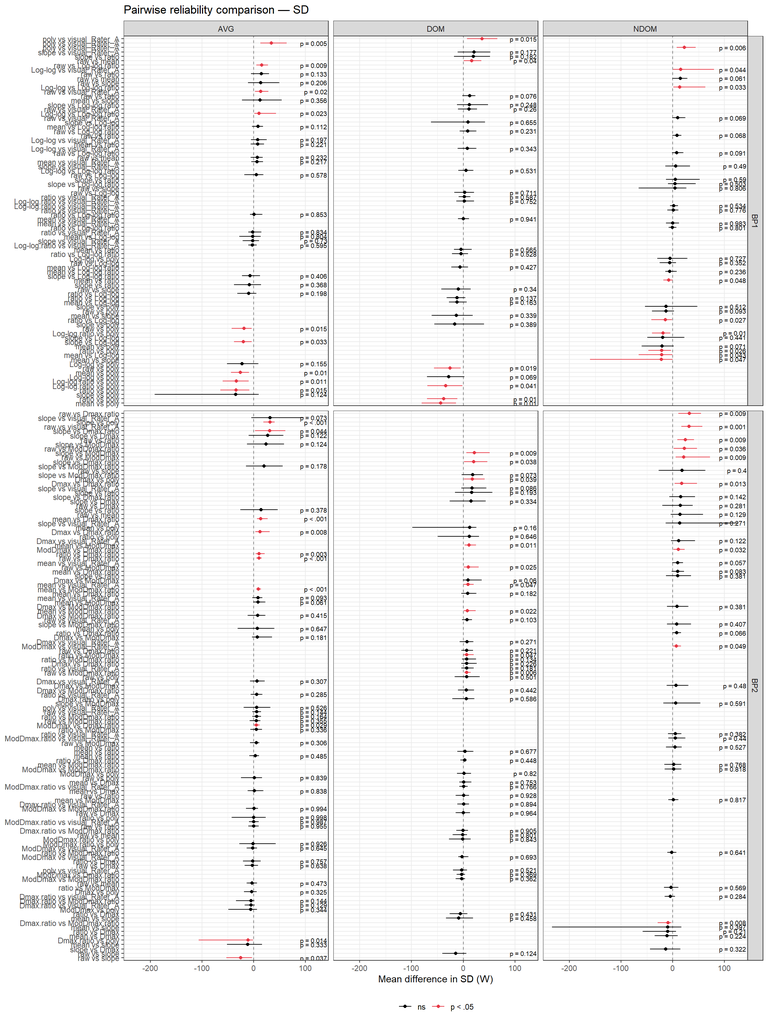

```r
set.seed(42)

boot_reli <- dat_all_wide |>
  group_by(channel, bp) |>
  nest() |>
  mutate(result = map(data, \(d) {
    pairs <- combn(unique(d$method), 2, simplify = FALSE)
    map_dfr(pairs, \(pair) {
      d_wide <- d |>
        filter(method %in% pair) |>
        pivot_wider(id_cols = id, names_from = method,
                    values_from = c(sd_power, cv_power))

      sd1 <- d_wide[[paste0("sd_power_", pair[1])]]
      sd2 <- d_wide[[paste0("sd_power_", pair[2])]]
      cv1 <- d_wide[[paste0("cv_power_", pair[1])]]
      cv2 <- d_wide[[paste0("cv_power_", pair[2])]]

      run_boot <- function(x, y) {
        ok <- !is.na(x) & !is.na(y)
        if (sum(ok) < 3) return(tibble(n = sum(ok), mean_diff = NA_real_,
                                       ci_lower = NA_real_, ci_upper = NA_real_,
                                       p_raw = NA_real_))
        res <- boot_t_test(x[ok], y[ok], paired = TRUE, R = 9999)
        tibble(n = sum(ok), mean_diff = mean(x[ok] - y[ok]),
               ci_lower = res$conf.int[1], ci_upper = res$conf.int[2],
               p_raw = res$p.value)
      }

      bind_rows(
        run_boot(sd1, sd2) |> mutate(metric = "SD"),
        run_boot(cv1, cv2) |> mutate(metric = "CV")
      ) |> mutate(method1 = pair[1], method2 = pair[2])
    })
  })) |>
  select(-data) |>
  unnest(result) |>
  mutate(
    sig  = p_raw < 0.05,
    pair = paste0(method1, " vs ", method2)
  )

# ── Figure: SD ────────────────────────────────────────────────────────────────
boot_reli |>
  filter(metric == "SD", !is.na(mean_diff)) |>
  anti_join(rename(exclude_combos, method1 = method), by = c("method1", "channel", "bp")) |>
  anti_join(rename(exclude_combos, method2 = method), by = c("method2", "channel", "bp")) |>
  mutate(
    p_label = case_when(
      p_raw < 0.001 ~ "p < .001",
      TRUE          ~ paste0("p = ", round(p_raw, 3))
    ),
    bp = factor(bp, levels = c(1, 2), labels = c("BP1", "BP2"))
  ) |>
  ggplot(aes(x = mean_diff, y = reorder_within(pair, mean_diff, list(channel, bp)))) +
  geom_vline(xintercept = 0, linetype = "dashed", color = "grey50") +
  geom_linerange(aes(xmin = ci_lower, xmax = ci_upper, color = sig)) +
  geom_point(aes(color = sig)) +
  geom_text(aes(x = Inf, label = p_label), hjust = 1.05, size = 2.5) +
  scale_y_reordered() +
  scale_color_manual(values = c("FALSE" = "black", "TRUE" = "#e63946"),
                     labels = c("ns", "p < .05")) +
  facet_grid(bp ~ channel, scales = "free_y", space = "free") +
  labs(x = "Mean difference in SD (W)", y = NULL, color = NULL,
       title = "Pairwise reliability comparison — SD") +
    theme(legend.position = "bottom")
```

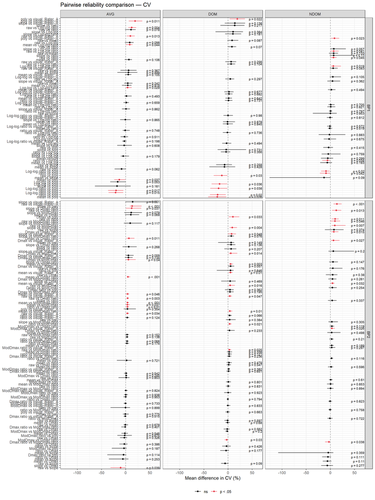

```r
# ── Figure: CV ────────────────────────────────────────────────────────────────
boot_reli |>
  filter(metric == "CV", !is.na(mean_diff)) |>
  anti_join(rename(exclude_combos, method1 = method), by = c("method1", "channel", "bp")) |>
  anti_join(rename(exclude_combos, method2 = method), by = c("method2", "channel", "bp")) |>
  mutate(
    p_label = case_when(
      p_raw < 0.001 ~ "p < .001",
      TRUE          ~ paste0("p = ", round(p_raw, 3))
    ),
    bp = factor(bp, levels = c(1, 2), labels = c("BP1", "BP2"))
  ) |>
  ggplot(aes(x = mean_diff, y = reorder_within(pair, mean_diff, list(channel, bp)))) +
  geom_vline(xintercept = 0, linetype = "dashed", color = "grey50") +
  geom_linerange(aes(xmin = ci_lower, xmax = ci_upper, color = sig)) +
  geom_point(aes(color = sig)) +
  geom_text(aes(x = Inf, label = p_label), hjust = 1.05, size = 2.5) +
  scale_y_reordered() +
  scale_color_manual(values = c("FALSE" = "black", "TRUE" = "#e63946"),
                     labels = c("ns", "p < .05")) +
  facet_grid(bp ~ channel, scales = "free_y", space = "free") +
  labs(x = "Mean difference in CV (%)", y = NULL, color = NULL,
       title = "Pairwise reliability comparison — CV") +
    theme(legend.position = "bottom")
```

## Summary

### Detection failure rates

```r
bp_failed |>
  mutate(
    bp    = factor(bp, levels = c(1, 2), labels = c("BP1", "BP2")),
    label = paste0(failed, "/", n_total, " (", pct_failed, "%)")
  ) |>
  group_by(method, channel) |>
  mutate(sort_key = mean(pct_failed)) |>
  ungroup() |>
  pivot_wider(
    id_cols    = c(method, channel, sort_key),
    names_from  = bp,
    values_from = label,
    values_fill = "0/0 (0%)"
  ) |>
  arrange(sort_key) |>
  select(-sort_key) |>
  knitr::kable(
    col.names = c("Method", "Channel", "BP1", "BP2"),
    caption   = "Table S1. Failed breakpoint detections per method and channel."
  )
```

Table S1. Failed breakpoint detections per method and channel.

[output not shown]

### Reliability statistics

```r
icc_all |>
  # filter(n >= 8) |>
  anti_join(exclude_combos, by = c("method", "channel", "bp")) |>
  mutate(
    BP     = factor(bp, levels = c(1, 2), labels = c("BP1", "BP2")),
    icc_ci = sprintf("%.2f [%.2f, %.2f]", icc, icc_lower, icc_upper),
    sem_r  = round(sem, 1),
    cv_pct = round(cv * 100, 1),
    mdc_r  = round(mdc95, 1)
  ) |>
  arrange(BP, sem) |>
  select(
    Method   = method,
    Channel  = channel,
    BP,
    n,
    `ICC(2,1) [95% CI]` = icc_ci,
    `SEM (W)`           = sem_r,
    `CV (%)`            = cv_pct,
    `MDC₉₅ (W)`        = mdc_r
  ) |>
  knitr::kable(caption = "Table 1. Test-retest reliability per method and channel (n >= 12).")
```

| Method | Channel | BP | n | ICC(2,1) [95% CI] | SEM (W) | CV (%) | MDC₉₅ (W) |
| --- | --- | --- | --- | --- | --- | --- | --- |
| Log-log.ratio | AVG | BP1 | 12 | 0.81 [0.63, 0.92] | 16.6 | 8.3 | 46.1 |
| ratio | DOM | BP1 | 11 | 0.53 [0.23, 0.79] | 17.5 | 10.2 | 48.4 |
| mean | NDOM | BP1 | 12 | 0.68 [0.43, 0.86] | 18.3 | 12.3 | 50.6 |
| visual_Rater_A | AVG | BP1 | 12 | 0.72 [0.50, 0.88] | 19.6 | 12.1 | 54.4 |
| slope | AVG | BP1 | 11 | 0.76 [0.54, 0.90] | 20.4 | 13.1 | 56.6 |
| visual_Rater_A | NDOM | BP1 | 12 | 0.67 [0.42, 0.85] | 21.1 | 12.7 | 58.4 |
| mean | DOM | BP1 | 12 | 0.61 [0.34, 0.82] | 21.7 | 15.2 | 60.3 |
| Log-log.ratio | NDOM | BP1 | 12 | 0.65 [0.40, 0.84] | 22.0 | 10.9 | 61.1 |
| ratio | AVG | BP1 | 12 | 0.47 [0.18, 0.74] | 23.4 | 13.6 | 64.8 |
| visual_Rater_A | DOM | BP1 | 12 | 0.71 [0.47, 0.87] | 23.5 | 14.2 | 65.3 |
| ratio | NDOM | BP1 | 12 | 0.59 [0.31, 0.81] | 23.9 | 13.2 | 66.2 |
| Log-log.ratio | DOM | BP1 | 12 | 0.66 [0.41, 0.85] | 24.6 | 12.4 | 68.2 |
| mean | AVG | BP1 | 12 | 0.46 [0.16, 0.73] | 26.1 | 18.0 | 72.3 |
| Log-log | DOM | BP1 | 12 | 0.54 [0.27, 0.78] | 29.0 | 13.3 | 80.5 |
| raw | NDOM | BP1 | 12 | 0.49 [0.21, 0.75] | 32.1 | 18.7 | 89.0 |
| Log-log | AVG | BP1 | 12 | 0.69 [0.45, 0.86] | 32.6 | 15.3 | 90.4 |
| raw | DOM | BP1 | 12 | 0.47 [0.17, 0.74] | 33.7 | 21.3 | 93.5 |
| raw | AVG | BP1 | 12 | 0.25 [-0.04, 0.58] | 34.2 | 22.0 | 94.7 |
| slope | DOM | BP1 | 10 | 0.00 [-0.20, 0.36] | 37.8 | 24.4 | 104.8 |
| slope | NDOM | BP1 | 11 | 0.28 [-0.02, 0.62] | 38.3 | 24.3 | 106.1 |
| Log-log | NDOM | BP1 | 12 | 0.52 [0.24, 0.77] | 41.2 | 20.5 | 114.3 |
| poly | NDOM | BP1 | 12 | 0.35 [0.05, 0.66] | 44.9 | 22.8 | 124.6 |
| poly | AVG | BP1 | 12 | 0.00 [-0.23, 0.35] | 62.5 | 34.4 | 173.3 |
| poly | DOM | BP1 | 12 | 0.03 [-0.21, 0.38] | 64.7 | 37.0 | 179.3 |
| poly | AVG | BP2 | 10 | 0.83 [0.30, 0.95] | 9.0 | 3.3 | 24.9 |
| Dmax.ratio | AVG | BP2 | 12 | 0.91 [0.82, 0.97] | 9.4 | 4.2 | 25.9 |
| poly | DOM | BP2 | 10 | 0.88 [0.73, 0.96] | 12.5 | 4.6 | 34.6 |
| Dmax.ratio | NDOM | BP2 | 12 | 0.83 [0.66, 0.93] | 13.2 | 6.0 | 36.5 |
| ModDmax | DOM | BP2 | 12 | 0.84 [0.69, 0.93] | 15.4 | 5.4 | 42.7 |
| visual_Rater_A | AVG | BP2 | 12 | 0.83 [0.67, 0.93] | 16.6 | 5.8 | 46.0 |
| visual_Rater_A | NDOM | BP2 | 12 | 0.80 [0.60, 0.92] | 16.9 | 5.9 | 46.8 |
| ModDmax | AVG | BP2 | 12 | 0.85 [0.70, 0.94] | 17.0 | 6.0 | 47.2 |
| raw | AVG | BP2 | 12 | 0.87 [0.73, 0.95] | 18.1 | 6.9 | 50.2 |
| visual_Rater_A | DOM | BP2 | 12 | 0.82 [0.65, 0.92] | 18.9 | 6.5 | 52.4 |
| Dmax.ratio | DOM | BP2 | 12 | 0.74 [0.53, 0.89] | 19.0 | 8.7 | 52.7 |
| ratio | NDOM | BP2 | 12 | 0.72 [0.49, 0.88] | 19.2 | 7.6 | 53.1 |
| ModDmax.ratio | AVG | BP2 | 12 | 0.77 [0.57, 0.90] | 19.7 | 7.4 | 54.7 |
| ModDmax.ratio | DOM | BP2 | 12 | 0.79 [0.60, 0.91] | 20.6 | 7.8 | 57.1 |
| ratio | DOM | BP2 | 11 | 0.63 [0.34, 0.84] | 21.5 | 8.4 | 59.5 |
| mean | NDOM | BP2 | 12 | 0.67 [0.41, 0.85] | 22.6 | 8.6 | 62.7 |
| ratio | AVG | BP2 | 12 | 0.70 [0.46, 0.87] | 23.4 | 9.4 | 64.9 |
| ModDmax.ratio | NDOM | BP2 | 12 | 0.63 [0.37, 0.83] | 24.0 | 9.3 | 66.5 |
| mean | AVG | BP2 | 12 | 0.60 [0.33, 0.82] | 25.3 | 10.1 | 70.0 |
| Dmax | DOM | BP2 | 12 | 0.55 [0.28, 0.79] | 25.9 | 11.5 | 71.7 |
| ModDmax | NDOM | BP2 | 12 | 0.71 [0.48, 0.87] | 26.5 | 9.5 | 73.3 |
| raw | DOM | BP2 | 12 | 0.70 [0.46, 0.87] | 27.0 | 10.2 | 75.0 |
| Dmax | AVG | BP2 | 12 | 0.75 [0.53, 0.89] | 27.4 | 12.2 | 76.1 |
| mean | DOM | BP2 | 12 | 0.47 [0.18, 0.74] | 29.2 | 11.8 | 80.9 |
| slope | NDOM | BP2 | 11 | 0.63 [0.36, 0.84] | 35.9 | 14.1 | 99.4 |
| Dmax | NDOM | BP2 | 12 | 0.59 [0.31, 0.81] | 38.5 | 17.4 | 106.8 |
| slope | DOM | BP2 | 10 | 0.54 [0.22, 0.80] | 38.5 | 15.1 | 106.8 |
| raw | NDOM | BP2 | 12 | 0.36 [0.06, 0.66] | 51.0 | 19.1 | 141.4 |
| slope | AVG | BP2 | 11 | 0.27 [-0.03, 0.62] | 54.3 | 21.2 | 150.5 |

### Channel differences (side comparisons)

Significant pairwise bootstrap comparisons between DOM, NDOM, and AVG.

```r
exclude_method_bp  <- exclude_combos |> distinct(method, bp)
side_diff_filtered <- side_diff_all |>
  filter(!is.na(p_raw)) |>
  anti_join(exclude_method_bp, by = c("method", "bp"))
n_side_total <- nrow(side_diff_filtered)
n_side_sig   <- sum(side_diff_filtered$sig)

side_diff_filtered |>
  filter(sig) |>
  mutate(
    bp      = factor(bp, levels = c(1, 2), labels = c("BP1", "BP2")),
    result  = sprintf("Δ = %.1f W [%.1f, %.1f], p = %.3f", mean_diff, ci_lower, ci_upper, p_raw)
  ) |>
  arrange(desc(abs(mean_diff))) |>
  select(
    Method     = method,
    BP         = bp,
    Comparison = comparison,
    n,
    Result     = result
  ) |>
  knitr::kable(
    caption = sprintf(
      "Table S2. Significant channel differences in breakpoint power output (%d of %d comparisons significant, n >= 12).",
      n_side_sig, n_side_total
    )
  )
```

Table S2. Significant channel differences in breakpoint power output (4 of 51 comparisons significant, n >= 12).

| Method | BP | Comparison | n | Result |
| --- | --- | --- | --- | --- |
| poly | BP1 | ndom_vs_avg | 33 | Δ = 19.7 W [4.0, 43.2], p = 0.010 |
| mean | BP2 | dom_vs_ndom | 23 | Δ = -17.7 W [-36.9, -1.3], p = 0.038 |
| raw | BP1 | ndom_vs_avg | 36 | Δ = 16.4 W [3.1, 32.3], p = 0.015 |
| visual_Rater_A | BP1 | ndom_vs_avg | 36 | Δ = 4.4 W [1.6, 9.6], p = 0.002 |

### Method reliability comparisons

Significant pairwise bootstrap comparisons of within-subject SD and CV between methods.

```r
boot_reli_filtered <- boot_reli |>
  filter(!is.na(p_raw)) |>
  anti_join(rename(exclude_combos, method1 = method), by = c("method1", "channel", "bp")) |>
  anti_join(rename(exclude_combos, method2 = method), by = c("method2", "channel", "bp"))

fmt_reli <- function(data) {
  data |>
    mutate(
      bp     = factor(bp, levels = c(1, 2), labels = c("BP1", "BP2")),
      result = sprintf("Δ = %.2f [%.2f, %.2f], p = %.3f", mean_diff, ci_lower, ci_upper, p_raw)
    ) |>
    arrange(desc(abs(mean_diff))) |>
    select(Channel = channel, BP = bp, Comparison = pair, n, Result = result)
}

# SD
sd_filtered <- boot_reli_filtered |> filter(metric == "SD")
fmt_reli(filter(sd_filtered, sig)) |>
  knitr::kable(
    caption = sprintf(
      "Table S3a. Significant pairwise differences in within-subject SD between methods (%d of %d comparisons significant, n >= 12).",
      sum(sd_filtered$sig), nrow(sd_filtered)
    )
  )
```

| Channel | BP | Comparison | n | Result |
| --- | --- | --- | --- | --- |
| DOM | BP1 | mean vs poly | 11 | Δ = -43.57 [-80.16, -13.65], p = 0.010 |
| DOM | BP1 | ratio vs poly | 10 | Δ = -37.63 [-70.04, -11.02], p = 0.010 |
| DOM | BP1 | poly vs visual_Rater_A | 12 | Δ = 36.25 [7.37, 66.23], p = 0.015 |
| AVG | BP1 | ratio vs poly | 11 | Δ = -34.07 [-64.50, -8.00], p = 0.015 |
| AVG | BP1 | poly vs visual_Rater_A | 11 | Δ = 33.96 [13.19, 63.97], p = 0.005 |
| DOM | BP1 | Log-log.ratio vs poly | 12 | Δ = -33.80 [-69.30, -1.85], p = 0.041 |
| AVG | BP1 | Log-log.ratio vs poly | 11 | Δ = -33.78 [-60.05, -9.85], p = 0.011 |
| NDOM | BP2 | raw vs Dmax.ratio | 12 | Δ = 32.06 [11.18, 54.57], p = 0.009 |
| AVG | BP2 | slope vs poly | 3 | Δ = 31.73 [19.01, 40.51], p = 0.000 |
| NDOM | BP2 | raw vs visual_Rater_A | 11 | Δ = 31.36 [16.83, 57.05], p = 0.001 |
| AVG | BP2 | slope vs Dmax.ratio | 6 | Δ = 30.88 [2.56, 61.57], p = 0.044 |
| AVG | BP1 | mean vs poly | 11 | Δ = -25.44 [-44.10, -9.26], p = 0.010 |
| DOM | BP1 | raw vs poly | 12 | Δ = -25.19 [-56.65, -4.98], p = 0.019 |
| AVG | BP2 | raw vs slope | 6 | Δ = -25.08 [-52.88, -3.29], p = 0.037 |
| NDOM | BP2 | raw vs ratio | 12 | Δ = 24.70 [8.63, 41.07], p = 0.009 |
| NDOM | BP2 | raw vs ModDmax.ratio | 12 | Δ = 22.80 [1.77, 46.82], p = 0.036 |
| NDOM | BP1 | poly vs visual_Rater_A | 11 | Δ = 22.22 [7.64, 44.67], p = 0.006 |
| DOM | BP2 | slope vs ModDmax | 7 | Δ = 21.76 [6.21, 51.59], p = 0.009 |
| NDOM | BP1 | mean vs slope | 5 | Δ = -21.70 [-159.90, -0.26], p = 0.047 |
| NDOM | BP1 | mean vs Log-log | 9 | Δ = -21.57 [-65.88, -0.62], p = 0.043 |
| NDOM | BP1 | ratio vs poly | 11 | Δ = -21.44 [-47.34, -3.57], p = 0.026 |
| NDOM | BP2 | raw vs ModDmax | 12 | Δ = 21.15 [5.66, 72.45], p = 0.009 |
| AVG | BP1 | slope vs Log-log | 6 | Δ = -20.25 [-37.74, -3.92], p = 0.033 |
| DOM | BP2 | slope vs Dmax.ratio | 7 | Δ = 20.17 [1.85, 46.70], p = 0.038 |
| NDOM | BP1 | Log-log.ratio vs poly | 11 | Δ = -18.73 [-40.40, -4.87], p = 0.010 |
| AVG | BP1 | raw vs poly | 11 | Δ = -18.33 [-42.23, -4.03], p = 0.015 |
| DOM | BP2 | Dmax vs poly | 6 | Δ = 17.93 [1.89, 41.41], p = 0.039 |
| NDOM | BP2 | Dmax vs Dmax.ratio | 12 | Δ = 17.26 [3.79, 47.30], p = 0.013 |
| DOM | BP1 | raw vs mean | 11 | Δ = 16.29 [0.80, 35.31], p = 0.040 |
| AVG | BP1 | raw vs Log-log.ratio | 12 | Δ = 15.70 [5.00, 27.84], p = 0.009 |
| NDOM | BP1 | Log-log vs visual_Rater_A | 12 | Δ = 15.65 [0.56, 79.74], p = 0.044 |
| NDOM | BP1 | ratio vs Log-log | 12 | Δ = -14.30 [-41.47, -1.68], p = 0.027 |
| AVG | BP2 | mean vs Dmax.ratio | 12 | Δ = 13.64 [6.73, 26.96], p = 0.001 |
| NDOM | BP1 | Log-log vs Log-log.ratio | 12 | Δ = 13.53 [1.18, 63.38], p = 0.033 |
| AVG | BP1 | raw vs visual_Rater_A | 12 | Δ = 13.51 [2.74, 28.32], p = 0.020 |
| AVG | BP2 | Dmax vs Dmax.ratio | 12 | Δ = 12.57 [3.51, 31.35], p = 0.008 |
| DOM | BP2 | mean vs ModDmax | 11 | Δ = 11.34 [2.96, 24.86], p = 0.011 |
| AVG | BP2 | Dmax.ratio vs poly | 5 | Δ = -11.13 [-106.13, -1.03], p = 0.014 |
| NDOM | BP2 | ModDmax vs Dmax.ratio | 12 | Δ = 10.92 [1.09, 23.39], p = 0.032 |
| AVG | BP2 | ratio vs Dmax.ratio | 12 | Δ = 10.42 [3.70, 21.26], p = 0.003 |
| AVG | BP1 | Log-log vs Log-log.ratio | 12 | Δ = 10.31 [1.58, 43.61], p = 0.023 |
| AVG | BP2 | raw vs Dmax.ratio | 12 | Δ = 10.24 [5.12, 15.42], p = 0.001 |
| DOM | BP2 | raw vs ModDmax | 12 | Δ = 9.77 [1.28, 29.82], p = 0.025 |
| NDOM | BP2 | Dmax.ratio vs ModDmax.ratio | 12 | Δ = -9.26 [-29.09, -2.46], p = 0.008 |
| DOM | BP2 | mean vs visual_Rater_A | 11 | Δ = 9.04 [0.12, 20.17], p = 0.047 |
| AVG | BP2 | mean vs ModDmax.ratio | 12 | Δ = 8.81 [4.92, 14.58], p = 0.000 |
| NDOM | BP1 | mean vs ratio | 9 | Δ = -8.04 [-18.45, -0.13], p = 0.048 |
| DOM | BP2 | mean vs ModDmax.ratio | 11 | Δ = 7.99 [1.07, 23.96], p = 0.022 |
| NDOM | BP2 | ModDmax vs visual_Rater_A | 11 | Δ = 7.03 [0.02, 16.24], p = 0.049 |
| DOM | BP2 | ratio vs ModDmax | 10 | Δ = 6.95 [0.14, 20.02], p = 0.047 |
| DOM | BP2 | raw vs ModDmax.ratio | 12 | Δ = 6.56 [2.02, 14.56], p = 0.006 |
| AVG | BP2 | ModDmax vs Dmax.ratio | 12 | Δ = 5.30 [0.62, 11.60], p = 0.029 |

```r
# CV
cv_filtered <- boot_reli_filtered |> filter(metric == "CV")
fmt_reli(filter(cv_filtered, sig)) |>
  knitr::kable(
    caption = sprintf(
      "Table S3b. Significant pairwise differences in CV between methods (%d of %d comparisons significant, n >= 12).",
      sum(cv_filtered$sig), nrow(cv_filtered)
    )
  )
```

| Channel | BP | Comparison | n | Result |
| --- | --- | --- | --- | --- |
| DOM | BP1 | mean vs poly | 11 | Δ = -22.33 [-41.04, -3.67], p = 0.026 |
| DOM | BP1 | ratio vs poly | 10 | Δ = -21.67 [-37.34, -4.58], p = 0.020 |
| AVG | BP1 | Log-log.ratio vs poly | 11 | Δ = -20.92 [-35.34, -5.26], p = 0.015 |
| AVG | BP1 | ratio vs poly | 11 | Δ = -19.86 [-36.43, -4.89], p = 0.017 |
| DOM | BP1 | poly vs visual_Rater_A | 12 | Δ = 19.38 [3.48, 35.02], p = 0.022 |
| DOM | BP1 | Log-log.ratio vs poly | 12 | Δ = -19.36 [-36.61, -1.21], p = 0.038 |
| AVG | BP1 | poly vs visual_Rater_A | 11 | Δ = 19.30 [6.13, 34.42], p = 0.011 |
| DOM | BP1 | Log-log vs poly | 12 | Δ = -17.49 [-34.01, -1.52], p = 0.036 |
| NDOM | BP2 | raw vs visual_Rater_A | 11 | Δ = 13.56 [6.68, 23.42], p = 0.001 |
| AVG | BP2 | slope vs poly | 3 | Δ = 13.45 [8.65, 32.79], p = 0.000 |
| AVG | BP1 | mean vs poly | 11 | Δ = -13.09 [-23.76, -0.75], p = 0.037 |
| DOM | BP1 | raw vs poly | 12 | Δ = -12.80 [-29.64, -1.44], p = 0.030 |
| AVG | BP1 | raw vs Log-log.ratio | 12 | Δ = 12.45 [5.34, 21.76], p = 0.004 |
| AVG | BP2 | slope vs Dmax.ratio | 6 | Δ = 12.36 [0.68, 32.37], p = 0.037 |
| NDOM | BP2 | raw vs Dmax.ratio | 12 | Δ = 12.33 [3.42, 22.62], p = 0.013 |
| AVG | BP2 | raw vs slope | 6 | Δ = -10.72 [-31.44, -0.95], p = 0.039 |
| DOM | BP2 | Dmax vs poly | 6 | Δ = 10.27 [1.51, 23.18], p = 0.033 |
| NDOM | BP2 | raw vs ratio | 12 | Δ = 9.98 [2.84, 17.32], p = 0.011 |
| AVG | BP1 | raw vs visual_Rater_A | 12 | Δ = 9.58 [2.37, 18.68], p = 0.013 |
| NDOM | BP2 | raw vs ModDmax.ratio | 12 | Δ = 9.50 [0.22, 20.48], p = 0.046 |
| NDOM | BP2 | raw vs ModDmax | 12 | Δ = 9.15 [2.78, 31.53], p = 0.007 |
| NDOM | BP1 | ratio vs poly | 11 | Δ = -9.08 [-21.59, -0.37], p = 0.042 |
| DOM | BP2 | slope vs ModDmax | 7 | Δ = 8.86 [3.46, 18.61], p = 0.004 |
| NDOM | BP1 | Log-log.ratio vs poly | 11 | Δ = -8.81 [-18.92, -1.67], p = 0.020 |
| NDOM | BP1 | poly vs visual_Rater_A | 11 | Δ = 8.70 [1.38, 18.21], p = 0.023 |
| AVG | BP1 | mean vs Log-log.ratio | 12 | Δ = 8.20 [0.34, 14.09], p = 0.044 |
| NDOM | BP2 | Dmax vs Dmax.ratio | 12 | Δ = 7.38 [1.67, 16.64], p = 0.015 |
| DOM | BP2 | slope vs visual_Rater_A | 7 | Δ = 7.35 [0.17, 16.63], p = 0.048 |
| NDOM | BP1 | raw vs Log-log.ratio | 12 | Δ = 7.02 [0.35, 17.21], p = 0.041 |
| AVG | BP2 | Dmax vs Dmax.ratio | 12 | Δ = 6.63 [1.62, 18.09], p = 0.011 |
| NDOM | BP1 | raw vs ratio | 12 | Δ = 6.60 [0.22, 13.07], p = 0.045 |
| NDOM | BP2 | Dmax vs visual_Rater_A | 11 | Δ = 6.58 [0.81, 18.94], p = 0.027 |
| NDOM | BP1 | Log-log vs Log-log.ratio | 12 | Δ = 6.33 [0.97, 22.10], p = 0.019 |
| NDOM | BP1 | ratio vs Log-log | 12 | Δ = -5.92 [-16.54, -0.41], p = 0.034 |
| DOM | BP2 | Dmax vs ModDmax | 12 | Δ = 5.90 [1.33, 19.23], p = 0.014 |
| AVG | BP2 | Dmax vs ModDmax | 12 | Δ = 5.64 [0.27, 20.84], p = 0.040 |
| DOM | BP2 | mean vs ModDmax | 11 | Δ = 5.47 [2.31, 10.42], p = 0.003 |
| DOM | BP2 | mean vs visual_Rater_A | 11 | Δ = 4.98 [1.44, 9.48], p = 0.010 |
| AVG | BP2 | mean vs Dmax.ratio | 12 | Δ = 4.74 [2.23, 9.29], p = 0.001 |
| NDOM | BP2 | mean vs visual_Rater_A | 8 | Δ = 4.41 [0.62, 8.73], p = 0.032 |
| DOM | BP2 | raw vs ModDmax | 12 | Δ = 4.30 [0.87, 14.22], p = 0.016 |
| AVG | BP2 | mean vs visual_Rater_A | 11 | Δ = 3.99 [0.07, 7.37], p = 0.046 |
| AVG | BP1 | Log-log vs Log-log.ratio | 12 | Δ = 3.98 [0.42, 12.21], p = 0.029 |
| DOM | BP2 | raw vs visual_Rater_A | 12 | Δ = 3.86 [0.04, 8.08], p = 0.047 |
| AVG | BP2 | raw vs Dmax.ratio | 12 | Δ = 3.83 [1.62, 6.78], p = 0.003 |
| AVG | BP2 | mean vs ModDmax.ratio | 12 | Δ = 3.76 [1.89, 6.59], p = 0.001 |
| AVG | BP2 | mean vs ModDmax | 12 | Δ = 3.75 [0.29, 8.73], p = 0.037 |
| AVG | BP2 | ratio vs Dmax.ratio | 12 | Δ = 3.74 [1.12, 7.10], p = 0.010 |
| DOM | BP2 | mean vs ModDmax.ratio | 11 | Δ = 3.61 [0.88, 8.62], p = 0.010 |
| AVG | BP2 | raw vs visual_Rater_A | 11 | Δ = 3.43 [0.34, 6.89], p = 0.034 |
| DOM | BP2 | ratio vs ModDmax | 10 | Δ = 3.28 [0.60, 7.30], p = 0.021 |
| NDOM | BP2 | ModDmax vs visual_Rater_A | 11 | Δ = 3.16 [0.44, 9.10], p = 0.026 |
| NDOM | BP2 | Dmax.ratio vs ModDmax.ratio | 12 | Δ = -2.83 [-11.01, -0.13], p = 0.038 |
| DOM | BP2 | ModDmax vs Dmax.ratio | 12 | Δ = -2.82 [-7.17, -0.25], p = 0.030 |
| DOM | BP2 | raw vs ModDmax.ratio | 12 | Δ = 2.55 [0.37, 6.40], p = 0.025 |

## Discussion

Frame conclusions carefully given n=12: distinguish between “method A showed better reliability” (descriptive) and “methods differed significantly in reliability” (inferential). With this sample size, absence of a significant difference is not equivalence.

## Future analyses

- **Bland-Altman plots (repeated-measures extension, Bland & Altman 2007).** With 3 trials there are 3 pairwise comparisons per participant (T1–T2, T1–T3, T2–T3); the repeated-measures version handles the non-independence of these pairs correctly. Would report bias and LoA with their own 95% CIs.